```python
import numpy as np
import pandas as pd
from tqdm import tqdm

import matplotlib.pyplot as plt
import seaborn as sns

plt.rcParams.update({
    "font.family": "serif",
    "font.size": 25
})
plt.style.use('ggplot')
cmap = plt.get_cmap('cubehelix')
```

# Chargement et nettoyage du jeu de données

```python
data_path = '../data'
data_filename = 'nba_logreg.csv'

nba_data = pd.read_csv(f'{data_path}/{data_filename}')
nba_data.head()
```

|  | Name | GP | MIN | PTS | FGM | FGA | FG% | 3P Made | 3PA | 3P% | ... | FTA | FT% | OREB | DREB | REB | AST | STL | BLK | TOV | TARGET_5Yrs |
| --- | --- | --- | --- | --- | --- | --- | --- | --- | --- | --- | --- | --- | --- | --- | --- | --- | --- | --- | --- | --- | --- |
| 0 | Brandon Ingram | 36 | 27.4 | 7.4 | 2.6 | 7.6 | 34.7 | 0.5 | 2.1 | 25.0 | ... | 2.3 | 69.9 | 0.7 | 3.4 | 4.1 | 1.9 | 0.4 | 0.4 | 1.3 | 0.0 |
| 1 | Andrew Harrison | 35 | 26.9 | 7.2 | 2.0 | 6.7 | 29.6 | 0.7 | 2.8 | 23.5 | ... | 3.4 | 76.5 | 0.5 | 2.0 | 2.4 | 3.7 | 1.1 | 0.5 | 1.6 | 0.0 |
| 2 | JaKarr Sampson | 74 | 15.3 | 5.2 | 2.0 | 4.7 | 42.2 | 0.4 | 1.7 | 24.4 | ... | 1.3 | 67.0 | 0.5 | 1.7 | 2.2 | 1.0 | 0.5 | 0.3 | 1.0 | 0.0 |
| 3 | Malik Sealy | 58 | 11.6 | 5.7 | 2.3 | 5.5 | 42.6 | 0.1 | 0.5 | 22.6 | ... | 1.3 | 68.9 | 1.0 | 0.9 | 1.9 | 0.8 | 0.6 | 0.1 | 1.0 | 1.0 |
| 4 | Matt Geiger | 48 | 11.5 | 4.5 | 1.6 | 3.0 | 52.4 | 0.0 | 0.1 | 0.0 | ... | 1.9 | 67.4 | 1.0 | 1.5 | 2.5 | 0.3 | 0.3 | 0.4 | 0.8 | 1.0 |

5 rows × 21 columns

```python
nba_data.drop_duplicates(inplace=True)
```

```python
nba_data.info()
```

```
<class 'pandas.core.frame.DataFrame'>
Index: 1328 entries, 0 to 1339
Data columns (total 21 columns):
 #   Column       Non-Null Count  Dtype
---  ------       --------------  -----
 0   Name         1328 non-null   object
 1   GP           1328 non-null   int64
 2   MIN          1328 non-null   float64
 3   PTS          1328 non-null   float64
 4   FGM          1328 non-null   float64
 5   FGA          1328 non-null   float64
 6   FG%          1328 non-null   float64
 7   3P Made      1328 non-null   float64
 8   3PA          1328 non-null   float64
 9   3P%          1318 non-null   float64
 10  FTM          1328 non-null   float64
 11  FTA          1328 non-null   float64
 12  FT%          1328 non-null   float64
 13  OREB         1328 non-null   float64
 14  DREB         1328 non-null   float64
 15  REB          1328 non-null   float64
 16  AST          1328 non-null   float64
 17  STL          1328 non-null   float64
 18  BLK          1328 non-null   float64
 19  TOV          1328 non-null   float64
 20  TARGET_5Yrs  1328 non-null   float64
dtypes: float64(19), int64(1), object(1)
memory usage: 228.2+ KB
```

Seule la colonne `3P%` a des valeurs manquantes : c'est quand un joueur ne tente pas de 3 pointer.

Deux stratégies de remplissages s'offrent à nous :

1. Remplir ces champs par des 0 pour signifier qu'il n'y a aucune tentative, seulement on perd l'information que le joueur n'a pas tenté de 3 Pointer
2. Remplir ces champs par des -1, on obtient ainsi une colonne utilisable (pas de `NaN`) où l'information que le joueur n'a pas tenté de 3 pointer est codée, seulement elle perd la cohérence du pourcentage de 3 Pointer réussis.

```python
nba_data['3P%'] = nba_data['3P%'].fillna(value=0)
```

```python
nba_data.describe()
```

|  | GP | MIN | PTS | FGM | FGA | FG% | 3P Made | 3PA | 3P% | FTM | FTA | FT% | OREB | DREB | REB | AST | STL | BLK | TOV | TARGET_5Yrs |
| --- | --- | --- | --- | --- | --- | --- | --- | --- | --- | --- | --- | --- | --- | --- | --- | --- | --- | --- | --- | --- |
| count | 1328.000000 | 1328.000000 | 1328.000000 | 1328.000000 | 1328.000000 | 1328.000000 | 1328.000000 | 1328.00000 | 1328.000000 | 1328.000000 | 1328.000000 | 1328.000000 | 1328.000000 | 1328.000000 | 1328.000000 | 1328.000000 | 1328.000000 | 1328.000000 | 1328.000000 | 1328.000000 |
| mean | 60.411145 | 17.634413 | 6.804217 | 2.630271 | 5.885542 | 44.184639 | 0.247741 | 0.77869 | 19.177485 | 1.298117 | 1.822139 | 70.325226 | 1.009714 | 2.027636 | 3.036446 | 1.551205 | 0.619051 | 0.368675 | 1.193599 | 0.620482 |
| std | 17.416688 | 8.322560 | 4.361669 | 1.684918 | 3.595394 | 6.132759 | 0.384548 | 1.06351 | 16.071943 | 0.987329 | 1.322653 | 10.562158 | 0.777551 | 1.362236 | 2.060241 | 1.475731 | 0.410972 | 0.429680 | 0.723966 | 0.485450 |
| min | 11.000000 | 3.100000 | 0.700000 | 0.300000 | 0.800000 | 23.800000 | 0.000000 | 0.00000 | 0.000000 | 0.000000 | 0.000000 | 0.000000 | 0.000000 | 0.200000 | 0.300000 | 0.000000 | 0.000000 | 0.000000 | 0.100000 | 0.000000 |
| 25% | 47.000000 | 10.875000 | 3.700000 | 1.400000 | 3.300000 | 40.200000 | 0.000000 | 0.00000 | 0.000000 | 0.600000 | 0.900000 | 64.700000 | 0.400000 | 1.000000 | 1.500000 | 0.600000 | 0.300000 | 0.100000 | 0.700000 | 0.000000 |
| 50% | 63.000000 | 16.100000 | 5.550000 | 2.100000 | 4.800000 | 44.100000 | 0.100000 | 0.30000 | 22.200000 | 1.000000 | 1.500000 | 71.250000 | 0.800000 | 1.700000 | 2.500000 | 1.100000 | 0.500000 | 0.200000 | 1.000000 | 1.000000 |
| 75% | 77.000000 | 22.900000 | 8.800000 | 3.400000 | 7.500000 | 47.900000 | 0.400000 | 1.12500 | 32.500000 | 1.600000 | 2.300000 | 77.600000 | 1.400000 | 2.600000 | 4.000000 | 2.000000 | 0.800000 | 0.500000 | 1.500000 | 1.000000 |
| max | 82.000000 | 40.900000 | 28.200000 | 10.200000 | 19.800000 | 73.700000 | 2.300000 | 6.50000 | 100.000000 | 7.700000 | 10.200000 | 100.000000 | 5.300000 | 9.600000 | 13.900000 | 10.600000 | 2.500000 | 3.900000 | 4.400000 | 1.000000 |

```python
target_field = 'TARGET_5Yrs'
```

# Visualisation de la cible

Quelques informations sur la distribution de la cible.

```python
nba_data[target_field].value_counts()[1]/nba_data.shape[0]
```

```
np.float64(0.6204819277108434)
```

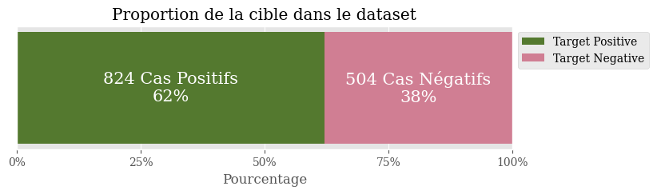

```python
fig, ax = plt.subplots(figsize=(8,2))
ax.set(**{
    'title':'Proportion de la cible dans le dataset',
    'xlabel':'Pourcentage',
    'xticks':np.arange(0,1.25,0.25),
    'xticklabels':[f'{x*100:0.0f}%' for x in np.arange(0,1.25,0.25)],
    'yticks':[],
    'xlim':(0,1)
})

rect = ax.barh(
    y=0,
    align='center',
    width=nba_data[target_field].value_counts()[1]/nba_data.shape[0],
    height=1,
    label='Target Positive',
    color=cmap(0.4)
)
ax.bar_label(
    container=rect,
    labels=[f'{nba_data[target_field].value_counts()[1]} Cas Positifs\n{100*nba_data[target_field].value_counts()[1]/nba_data.shape[0]:0.0f}%'],
    label_type='center',
    color='white',
    fontsize=15
)

rect = ax.barh(
    y=0,
    align='center',
    left=nba_data[target_field].value_counts()[1]/nba_data.shape[0],
    width=nba_data[target_field].value_counts()[0]/nba_data.shape[0],
    height=1,
    label='Target Negative',
    color=cmap(0.6)
)

ax.bar_label(
    container=rect,
    labels=[f'{nba_data[target_field].value_counts()[0]} Cas Négatifs\n{100*nba_data[target_field].value_counts()[0]/nba_data.shape[0]:0.0f}%'],
    label_type='center',
    color='white',
    fontsize=15
)
ax.legend(bbox_to_anchor=(1,1))
```

Premièrement, on voit que le dataset contient un peu plus de de cas positif (ayant tenus plus de 5 ans) que de cas négatif. Les proportions indiquent quand même qu'on n'est pas dans un cas exacerbé de déséquilibre de classe.

Puisque le déséquilibre n'est pas trop marquant je choisis de ne pas appliquer de stratégie de rééquilibrage de classe.

Deuxièmement, si on interprète de manière naïve la proportion de 62% de cas positif on pourrait dire que pour tester un modèle il faudrait au moins faire mieux que 62% de cas positifs pour être sûr que le modèle est meilleur que le hasard.

# Visualisation des variables

## Visualisation globale

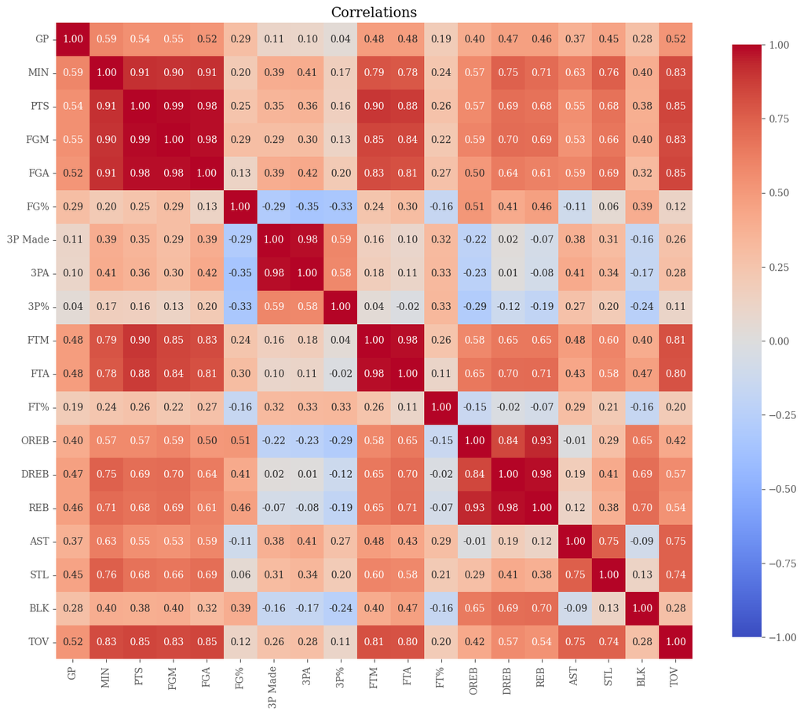

```python
correlation_matrix = nba_data.drop(columns=[target_field, 'Name']).corr()

fig, ax = plt.subplots(figsize=(15,15))

ax.set(**{
    'title':'Correlations'
})

sns.heatmap(
    data=correlation_matrix,
    annot=True,
    fmt='0.2f',
    cmap='coolwarm',
    vmin=-1,
    vmax=1,
    center=0,
    square=True,
    linewidths=0,
    cbar_kws={'shrink':0.75},
    ax=ax
)
ax.tick_params(axis='x', labelrotation=90)
ax.tick_params(axis='y', labelrotation=0)
```

La matrice des correlations montre que beaucoup de variables sont corellées entre elles.

En effet si on donne le seuil de 60% comme indicateur de correlation excessive on a la matrice suivante :

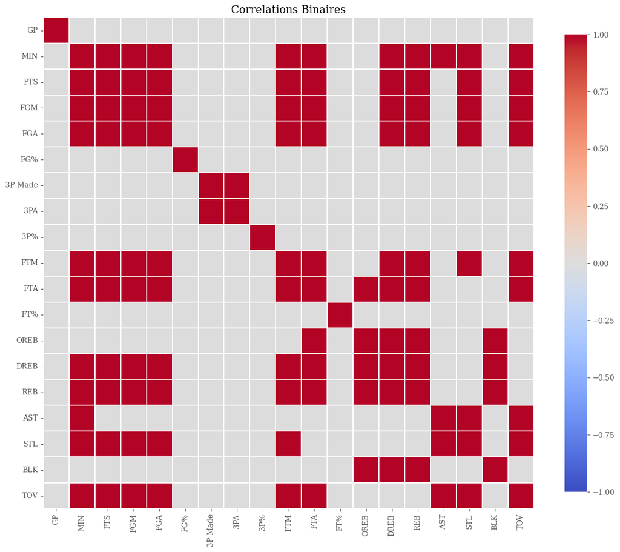

```python
correlation_matrix_binary = correlation_matrix.applymap(lambda x: 1 if abs(x)>=0.6 else 0)

fig, ax = plt.subplots(figsize=(15,15))

ax.set(**{
    'title':'Correlations Binaires'
})

sns.heatmap(
    data=correlation_matrix_binary,
    annot=False,
    fmt='0.2f',
    cmap='coolwarm',
    vmin=-1,
    vmax=1,
    center=0,
    square=True,
    linewidths=0.1,
    cbar_kws={'shrink':0.75},
    ax=ax
)
ax.tick_params(axis='x', labelrotation=90
)
ax.tick_params(axis='y', labelrotation=0)
```

Conclusion : les variables sont correlées il va falloir étudier une stratégie pour gérer ce problème. Plusieurs solutions s'offrent à nous à priori, parmi toutes les façons de procéder j'identifie les quatre suivantes qui me semble le plus pertinentes :

1. Supprimer à la mains les variables trop correlées
2. Utiliser un algorithme de sélection de variables
3. Recombiner les variables pour en créer des statistiquement indépendantes (Analyse en Composante Principale)
4. Faire une regression logistique et supprimer les variables don les coefficients sont trop faibles

Entrainons d'abord quelques modèles afin de voir si c'est nécessaire, peut être que certains modèles vont savoir traiter ces corrélations.

## Visualisation des variables

On veut avoir une idée de comment les variables sont distribuées, on pourra ainsi décider s'il peut être judicieux ou non de les transformer (les centrer, changer les proportions etc ...). Pour avoir des informations en plus par rapport à la cible on trace deux distributions : une pour la cible positive et une pour la cible négative. On pourra ainsi déterminer l'impact de la cible sur la distribution des variables et peut être appliquer des transformations intéressantes qui utilisent cette différence de comportement.

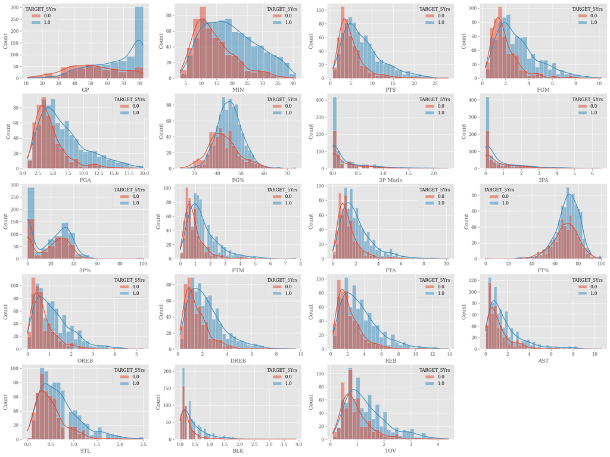

```python
features_names = np.array(nba_data.drop(columns=[target_field, 'Name']).columns)

fig, ax = plt.subplots(nrows=5,ncols=4, figsize=(24,18))

for a, feature_name in zip(ax.flatten(), features_names):
    sns.histplot(
        data=nba_data,
        x=feature_name,
        hue=target_field,
        kde=True,
        ax=a
    )
ax.flatten()[-1].remove()
```

La plupart des variables ont une distributions "quasi-identique" qu'elles soient conditionnées par une cible réussie ou ratée. On peut néanmoins remarquer que les variables suivantes : `GP`, `MIN`, `FG%` et `FT%` ont des comportements légèrement différents selon le conditionnement.

Pour une variable comme `GP` (Games Played), cela tient juste du fait que les joueurs ayant effectivement passés 5 ans de carrière ont plus de temps de jeu (puisqu'ils ont au moins 5 saisons à leur actif). Il est donc normal d'observer la différence de distribution.

Pour d'autres variables c'est moins clair, par exemple le `FG%` (pourcentage de Field Goals réussis), cela dépend du comportement du joueur. Un modèle pourra par exemple utiliser ces différences en comportement pour prédire la cible.

D'une manière générale les variables sont assez "collées" (skewed), on peut donc penser qu'il sera judicieux de les recentrer et de les normaliser.

# Entrainement de modèle

## Façon de tester les modèles

Les investisseurs veulent maximiser le *recall*. Pour rappel le *recall* est défini par :

$$\mathsf{Recall} = \frac{\mathsf{Vrais\ Positifs}}{\mathsf{Vrais\ Positifs} + \mathsf{Faux\ Négatifs}}$$

C'est à dire, la proportion de joueurs que le modèle prédit comme bons sur la proportion totale de joueurs bons dans le dataset. Les investisseurs veulent être sûr que le modèle ne rate pas les bons joueurs.

Pour tester le *recall* d'un modèle, je vais garder la stratégie de validation croisée présente dans le fichier `test.py`.

Cette stratégie consiste à séparer le jeu de données en 3 parties au hasard, à entrainer un modèle sur chaque paire de parties et à les tester sur la partie sur laquelle ils n'ont pas été entrainés, puis à tester le recall sur chaque modèle et à en faire la moyenne.

Cette stratégie permet de s'assurer que le modèle est un peu robuste à la variation des données. Dans l'idéal on aurait un jeu de validation final indépendant du jeu d'entrainement et de test.

## Quels modèles tester

On va tester des modèles basiques sans optimiser leurs paramètres.

1. Régression Logistique sans régularisation car je n'ai pas d'à priori sur la donnée
2. Arbre de Décision
3. Support Vector Classifier non linéaire
4. Support Vector Classifier linéaire

À mon avis c'est suffisant dans un premier temps.

```python
from sklearn.linear_model import LogisticRegression
from sklearn.svm import SVC, LinearSVC
from sklearn.tree import DecisionTreeClassifier

from test import score_classifier
```

```python
classifiers_dict = {
        'Regression Logistique':LogisticRegression(),
        'Arbre de Décision':DecisionTreeClassifier(),
        'Support Vector Classifier - Non Linéaire':SVC(),
        'Support Vector Classifier - Linéaire':LinearSVC()
}
```

```python
results_nba_raw = score_classifier(
        dataset=nba_data[features_names],
        labels=nba_data[target_field],
        classifiers_dict=classifiers_dict
)
```

[output not shown]

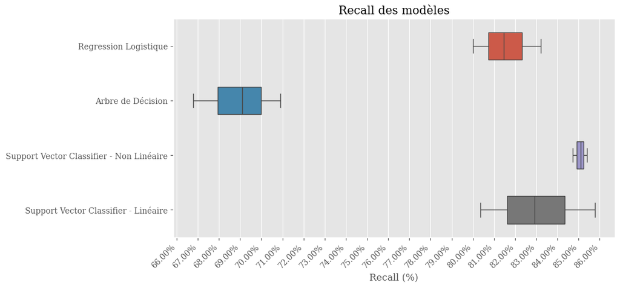

```python
fig, ax = plt.subplots(figsize=(10,5))

ax.set(**{
        'title':'Recall des modèles',
        'xlabel':'Recall (%)',
        'xticks':np.arange(0,1.1,0.01),
        'xticklabels':[f'{100*x:0.02f}%' for x in np.arange(0,1.1,0.01)]
})


sns.boxplot(
        data=results_nba_raw,
        ax=ax,
        orient='h',
        width=0.5
)
# make x ticks rotate by 45 degrees
ax.set_xticklabels(ax.get_xticklabels(), rotation=45, ha='right')
```

On voit que le meilleur modèle est le Support Vector Classifier non Linéaire, en effet il présente le meilleur score et la plus petite variance autour de ce score.

Je pense qu'il faut à présent travailler sur ce modèles, essayer de trouver des paramètres qui vont améliorer les performances.

### Affinement du modèle

Pour faire ça on va faire une simple recherche en force brute en utilisant un `GridSearchCV` de `sklearn`

```python
from sklearn.model_selection import GridSearchCV
```

```python
svc_param_grid = {
        'C':[0.01, 0.1, 1],
        'gamma':[0.01, 0.1, 1],
        'kernel':['rbf'] # Pas de noyau linéaire car on a déjà testé le LinearSVC
}

grid_search = GridSearchCV(
        estimator= SVC(),
        param_grid=svc_param_grid,
        n_jobs=4,
        cv=3,
)
```

```python
grid_search.fit(
        X=nba_data[features_names],
        y=nba_data[target_field]
)
```

```
GridSearchCV(cv=3, estimator=SVC(), n_jobs=4,
             param_grid={'C': [0.01, 0.1, 1], 'gamma': [0.01, 0.1, 1],
                         'kernel': ['rbf']})
```

```python
print(f'Meilleurs paramètres : {grid_search.best_params_}')
```

```
Meilleurs paramètres : {'C': 1, 'gamma': 0.01, 'kernel': 'rbf'}
```

```python
from sklearn.metrics import recall_score, confusion_matrix, accuracy_score, f1_score
```

```python
from sklearn.model_selection import train_test_split
```

```python
X_train, X_test, y_train, y_test = train_test_split(nba_data[features_names], nba_data[target_field], test_size=0.65, random_state=50, shuffle=True)
best_params = grid_search.best_params_

best_SVC = SVC().fit(X_train, y_train)
y_pred = best_SVC.predict(X_test)
```

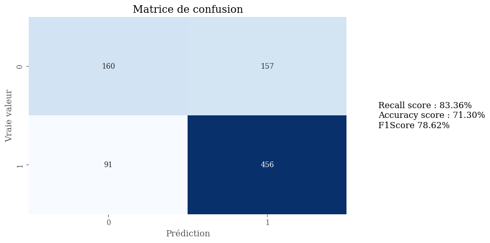

```python
# make nice plot of confusion matrix with recall score and accuracy on the side

import seaborn as sns
import matplotlib.pyplot as plt

# compute confusion matrix

conf_matrix = confusion_matrix(y_test, y_pred)

# compute recall score

recall_score_nba = recall_score(y_test, y_pred)

# compute accuracy score

accuracy_score_nba = accuracy_score(y_test, y_pred)

# compute f1 score

f1_score_nba = f1_score(y_test, y_pred)

# make nice plot of confusion matrix with recall score and accuracy on the side

fig, ax = plt.subplots(figsize=(10,5))

sns.heatmap(conf_matrix, annot=True, fmt='d', cmap='Blues', ax=ax)

ax.set(
        title='Matrice de confusion',
        xlabel='Prédiction',
        ylabel='Vraie valeur'
)

ax.text(
        x=1.1,
        y=0.5,
        s=f'Recall score : {100*recall_score_nba:0.2f}%\nAccuracy score : {100*accuracy_score_nba:0.2f}%\nF1Score {100*f1_score_nba:0.2f}%',
        fontsize=12,
        horizontalalignment='left',
        verticalalignment='center',
        transform=ax.transAxes
)
ax.get_figure().axes[-1].set_visible(False)
```

```python
import joblib
```

```python
joblib.dump(value=best_SVC, filename='../models/model.pkl')
```

```
['../models/model.pkl']
```

```python
import yaml
```

```python
with open('../data/features_names.yaml', 'w') as file:
        yaml.dump({'features_names':features_names.tolist()}, file)
```